# Capstone Project

```python
import numpy as np
import pandas as pd
import matplotlib.pyplot as plt
import seaborn as sns

pd.set_option('display.max_rows' , None)

import warnings
warnings.filterwarnings("ignore")
```

## Problem -1

#### Collating all the data for easier anlysis

```python
Hospital = pd.read_csv("Hospitalisation details.csv")
Medical = pd.read_csv("Medical Examinations.csv")
Names = pd.read_excel("Names.xlsx")
```

## Problem -2

### checking Null Value in Dataset

```python
Hospital.isnull().sum()
```

```
Customer ID      0
year             0
month            0
date             0
children         0
charges          0
Hospital tier    0
City tier        0
State ID         0
dtype: int64
```

```python
Medical.isnull().sum()
```

```
Customer ID               0
BMI                       0
HBA1C                     0
Heart Issues              0
Any Transplants           0
Cancer history            0
NumberOfMajorSurgeries    0
smoker                    0
dtype: int64
```

```python
Names.isnull().sum()
```

```
Customer ID    0
name           0
dtype: int64
```

```python
Hospital.head()
```

|  | Customer ID | year | month | date | children | charges | Hospital tier | City tier | State ID |
| --- | --- | --- | --- | --- | --- | --- | --- | --- | --- |
| 0 | Id2335 | 1992 | Jul | 9 | 0 | 563.84 | tier - 2 | tier - 3 | R1013 |
| 1 | Id2334 | 1992 | Nov | 30 | 0 | 570.62 | tier - 2 | tier - 1 | R1013 |
| 2 | Id2333 | 1993 | Jun | 30 | 0 | 600.00 | tier - 2 | tier - 1 | R1013 |
| 3 | Id2332 | 1992 | Sep | 13 | 0 | 604.54 | tier - 3 | tier - 3 | R1013 |
| 4 | Id2331 | 1998 | Jul | 27 | 0 | 637.26 | tier - 3 | tier - 3 | R1013 |

```python
Medical.head()
```

|  | Customer ID | BMI | HBA1C | Heart Issues | Any Transplants | Cancer history | NumberOfMajorSurgeries | smoker |
| --- | --- | --- | --- | --- | --- | --- | --- | --- |
| 0 | Id1 | 47.410 | 7.47 | No | No | No | No major surgery | yes |
| 1 | Id2 | 30.360 | 5.77 | No | No | No | No major surgery | yes |
| 2 | Id3 | 34.485 | 11.87 | yes | No | No | 2 | yes |
| 3 | Id4 | 38.095 | 6.05 | No | No | No | No major surgery | yes |
| 4 | Id5 | 35.530 | 5.45 | No | No | No | No major surgery | yes |

```python
Names.head()
```

|  | Customer ID | name |
| --- | --- | --- |
| 0 | Id1 | Hawks, Ms. Kelly |
| 1 | Id2 | Lehner, Mr. Matthew D |
| 2 | Id3 | Lu, Mr. Phil |
| 3 | Id4 | Osborne, Ms. Kelsey |
| 4 | Id5 | Kadala, Ms. Kristyn |

```python
Hospital.shape
```

```
(2343, 9)
```

```python
Medical.shape
```

```
(2335, 8)
```

```python
Names.shape
```

```
(2335, 2)
```

#### concluded that there is no null value available in the dataset

```python
Hospital.columns
```

```
Index(['Customer ID', 'year', 'month', 'date', 'children', 'charges',
       'Hospital tier', 'City tier', 'State ID'],
      dtype='object')
```

```python
merge_data = pd.merge(Hospital,Medical, on = 'Customer ID')
```

```python
merge_data.head()
```

|  | Customer ID | year | month | date | children | charges | Hospital tier | City tier | State ID | BMI | HBA1C | Heart Issues | Any Transplants | Cancer history | NumberOfMajorSurgeries | smoker |
| --- | --- | --- | --- | --- | --- | --- | --- | --- | --- | --- | --- | --- | --- | --- | --- | --- |
| 0 | Id2335 | 1992 | Jul | 9 | 0 | 563.84 | tier - 2 | tier - 3 | R1013 | 17.58 | 4.51 | No | No | No | 1 | No |
| 1 | Id2334 | 1992 | Nov | 30 | 0 | 570.62 | tier - 2 | tier - 1 | R1013 | 17.60 | 4.39 | No | No | No | 1 | No |
| 2 | Id2333 | 1993 | Jun | 30 | 0 | 600.00 | tier - 2 | tier - 1 | R1013 | 16.47 | 6.35 | No | No | Yes | 1 | No |
| 3 | Id2332 | 1992 | Sep | 13 | 0 | 604.54 | tier - 3 | tier - 3 | R1013 | 17.70 | 6.28 | No | No | No | 1 | No |
| 4 | Id2331 | 1998 | Jul | 27 | 0 | 637.26 | tier - 3 | tier - 3 | R1013 | 22.34 | 5.57 | No | No | No | 1 | No |

```python
master_data = pd.merge(merge_data,Names , on= 'Customer ID')
```

```python
master_data.info()
```

```
<class 'pandas.core.frame.DataFrame'>
RangeIndex: 2335 entries, 0 to 2334
Data columns (total 17 columns):
 #   Column                  Non-Null Count  Dtype
---  ------                  --------------  -----
 0   Customer ID             2335 non-null   object
 1   year                    2335 non-null   object
 2   month                   2335 non-null   object
 3   date                    2335 non-null   int64
 4   children                2335 non-null   int64
 5   charges                 2335 non-null   float64
 6   Hospital tier           2335 non-null   object
 7   City tier               2335 non-null   object
 8   State ID                2335 non-null   object
 9   BMI                     2335 non-null   float64
 10  HBA1C                   2335 non-null   float64
 11  Heart Issues            2335 non-null   object
 12  Any Transplants         2335 non-null   object
 13  Cancer history          2335 non-null   object
 14  NumberOfMajorSurgeries  2335 non-null   object
 15  smoker                  2335 non-null   object
 16  name                    2335 non-null   object
dtypes: float64(3), int64(2), object(12)
memory usage: 310.2+ KB
```

```python
master_data['City tier'].head()
```

```
0    tier - 3
1    tier - 1
2    tier - 1
3    tier - 3
4    tier - 3
Name: City tier, dtype: object
```

```python
master_data.columns = master_data.columns.str.lower()
master_data.columns = master_data.columns.str.replace(' ','_')
master_data.columns
```

```
Index(['customer_id', 'year', 'month', 'date', 'children', 'charges',
       'hospital_tier', 'city_tier', 'state_id', 'bmi', 'hba1c',
       'heart_issues', 'any_transplants', 'cancer_history',
       'numberofmajorsurgeries', 'smoker', 'name'],
      dtype='object')
```

```python
master_data.head()
```

|  | customer_id | year | month | date | children | charges | hospital_tier | city_tier | state_id | bmi | hba1c | heart_issues | any_transplants | cancer_history | numberofmajorsurgeries | smoker | name |
| --- | --- | --- | --- | --- | --- | --- | --- | --- | --- | --- | --- | --- | --- | --- | --- | --- | --- |
| 0 | Id2335 | 1992 | Jul | 9 | 0 | 563.84 | tier - 2 | tier - 3 | R1013 | 17.58 | 4.51 | No | No | No | 1 | No | German, Mr. Aaron K |
| 1 | Id2334 | 1992 | Nov | 30 | 0 | 570.62 | tier - 2 | tier - 1 | R1013 | 17.60 | 4.39 | No | No | No | 1 | No | Rosendahl, Mr. Evan P |
| 2 | Id2333 | 1993 | Jun | 30 | 0 | 600.00 | tier - 2 | tier - 1 | R1013 | 16.47 | 6.35 | No | No | Yes | 1 | No | Albano, Ms. Julie |
| 3 | Id2332 | 1992 | Sep | 13 | 0 | 604.54 | tier - 3 | tier - 3 | R1013 | 17.70 | 6.28 | No | No | No | 1 | No | Riveros Gonzalez, Mr. Juan D. Sr. |
| 4 | Id2331 | 1998 | Jul | 27 | 0 | 637.26 | tier - 3 | tier - 3 | R1013 | 22.34 | 5.57 | No | No | No | 1 | No | Brietzke, Mr. Jordan |

```python
master_data.info()
```

```
<class 'pandas.core.frame.DataFrame'>
RangeIndex: 2335 entries, 0 to 2334
Data columns (total 17 columns):
 #   Column                  Non-Null Count  Dtype
---  ------                  --------------  -----
 0   customer_id             2335 non-null   object
 1   year                    2335 non-null   object
 2   month                   2335 non-null   object
 3   date                    2335 non-null   int64
 4   children                2335 non-null   int64
 5   charges                 2335 non-null   float64
 6   hospital_tier           2335 non-null   object
 7   city_tier               2335 non-null   object
 8   state_id                2335 non-null   object
 9   bmi                     2335 non-null   float64
 10  hba1c                   2335 non-null   float64
 11  heart_issues            2335 non-null   object
 12  any_transplants         2335 non-null   object
 13  cancer_history          2335 non-null   object
 14  numberofmajorsurgeries  2335 non-null   object
 15  smoker                  2335 non-null   object
 16  name                    2335 non-null   object
dtypes: float64(3), int64(2), object(12)
memory usage: 310.2+ KB
```

```python
master_data.describe()
```

|  | date | children | charges | bmi | hba1c |
| --- | --- | --- | --- | --- | --- |
| count | 2335.000000 | 2335.000000 | 2335.000000 | 2335.000000 | 2335.000000 |
| mean | 15.563597 | 1.025696 | 13529.918034 | 30.972649 | 6.578998 |
| std | 8.720508 | 1.234754 | 11898.654299 | 8.742095 | 2.228731 |
| min | 1.000000 | 0.000000 | 563.840000 | 15.010000 | 4.000000 |
| 25% | 8.000000 | 0.000000 | 5084.010000 | 24.600000 | 4.900000 |
| 50% | 15.000000 | 0.000000 | 9630.910000 | 30.400000 | 5.810000 |
| 75% | 23.000000 | 2.000000 | 16912.295000 | 36.300000 | 7.955000 |
| max | 30.000000 | 5.000000 | 63770.430000 | 55.050000 | 12.000000 |

### Problem -3

#### Find the percentage of rows that have trivial value (for example, ?),and delete such rows if they do not contain significant information

```python
(master_data == '?').sum()
```

```
customer_id               0
year                      2
month                     3
date                      0
children                  0
charges                   0
hospital_tier             1
city_tier                 1
state_id                  2
bmi                       0
hba1c                     0
heart_issues              0
any_transplants           0
cancer_history            0
numberofmajorsurgeries    0
smoker                    2
name                      0
dtype: int64
```

```python
perc_data_col = ((master_data=='?').sum(axis=1)/(master_data.shape[1]))*100
perc_data_col[perc_data_col>0]
```

```
11       5.882353
13       5.882353
17      11.764706
542      5.882353
1046     5.882353
1049     5.882353
1700     5.882353
1775     5.882353
2165     5.882353
2332     5.882353
dtype: float64
```

```python
perc_data_col[perc_data_col>0].index # to find the trivial value location
```

```
Index([11, 13, 17, 542, 1046, 1049, 1700, 1775, 2165, 2332], dtype='int64')
```

```python
perc_data_row = (((master_data=='?').sum())/master_data.shape[0])*100
perc_data_row.sort_values(ascending=False)
```

```
month                     0.128480
state_id                  0.085653
smoker                    0.085653
year                      0.085653
hospital_tier             0.042827
city_tier                 0.042827
heart_issues              0.000000
numberofmajorsurgeries    0.000000
cancer_history            0.000000
any_transplants           0.000000
customer_id               0.000000
hba1c                     0.000000
bmi                       0.000000
charges                   0.000000
children                  0.000000
date                      0.000000
name                      0.000000
dtype: float64
```

```python
master_notv = master_data.drop(index = perc_data_col[perc_data_col>0].index)
```

```python
(master_notv =='?').sum()
```

```
customer_id               0
year                      0
month                     0
date                      0
children                  0
charges                   0
hospital_tier             0
city_tier                 0
state_id                  0
bmi                       0
hba1c                     0
heart_issues              0
any_transplants           0
cancer_history            0
numberofmajorsurgeries    0
smoker                    0
name                      0
dtype: int64
```

- `dropped all the "?" from the data`

### Problem - 4

#### Use the necessary transformation methods to deal with the nominal and ordinal categorical variables in the dataset

```python
master_notv[['hospital_tier', 'city_tier']].head()
```

|  | hospital_tier | city_tier |
| --- | --- | --- |
| 0 | tier - 2 | tier - 3 |
| 1 | tier - 2 | tier - 1 |
| 2 | tier - 2 | tier - 1 |
| 3 | tier - 3 | tier - 3 |
| 4 | tier - 3 | tier - 3 |

```python
master_data.state_id.value_counts()[:3]
```

```
state_id
R1013    612
R1012    575
R1011    574
Name: count, dtype: int64
```

```python
# import ordinalEncoder to deal with ordinal categorical variables - city tier and hospital tier
from sklearn.preprocessing import OrdinalEncoder
```

```python
ordinal = OrdinalEncoder(categories= [['tier - 3', 'tier - 2', 'tier - 1'],['tier - 3', 'tier - 2', 'tier - 1']])
master_notv[['city_tier_ord', 'hospital_tier_ord']] = ordinal.fit_transform(master_notv[['city_tier', 'hospital_tier']])
```

```python
pd.crosstab(master_notv['city_tier_ord'],master_notv['city_tier'])
```

| city_tier city_tier_ord | tier - 1 | tier - 2 | tier - 3 |
| --- | --- | --- | --- |
| 0.0 | 0 | 0 | 789 |
| 1.0 | 0 | 807 | 0 |
| 2.0 | 729 | 0 | 0 |

```python
pd.crosstab(master_notv['hospital_tier_ord'],[master_notv['hospital_tier']])
```

| hospital_tier hospital_tier_ord | tier - 1 | tier - 2 | tier - 3 |
| --- | --- | --- | --- |
| 0.0 | 0 | 0 | 691 |
| 1.0 | 0 | 1334 | 0 |
| 2.0 | 300 | 0 | 0 |

```python
# Create dummies
```

```python
master_notv.head()
```

|  | customer_id | year | month | date | children | charges | hospital_tier | city_tier | state_id | bmi | hba1c | heart_issues | any_transplants | cancer_history | numberofmajorsurgeries | smoker | name | city_tier_ord | hospital_tier_ord |
| --- | --- | --- | --- | --- | --- | --- | --- | --- | --- | --- | --- | --- | --- | --- | --- | --- | --- | --- | --- |
| 0 | Id2335 | 1992 | Jul | 9 | 0 | 563.84 | tier - 2 | tier - 3 | R1013 | 17.58 | 4.51 | No | No | No | 1 | No | German, Mr. Aaron K | 0.0 | 1.0 |
| 1 | Id2334 | 1992 | Nov | 30 | 0 | 570.62 | tier - 2 | tier - 1 | R1013 | 17.60 | 4.39 | No | No | No | 1 | No | Rosendahl, Mr. Evan P | 2.0 | 1.0 |
| 2 | Id2333 | 1993 | Jun | 30 | 0 | 600.00 | tier - 2 | tier - 1 | R1013 | 16.47 | 6.35 | No | No | Yes | 1 | No | Albano, Ms. Julie | 2.0 | 1.0 |
| 3 | Id2332 | 1992 | Sep | 13 | 0 | 604.54 | tier - 3 | tier - 3 | R1013 | 17.70 | 6.28 | No | No | No | 1 | No | Riveros Gonzalez, Mr. Juan D. Sr. | 0.0 | 0.0 |
| 4 | Id2331 | 1998 | Jul | 27 | 0 | 637.26 | tier - 3 | tier - 3 | R1013 | 22.34 | 5.57 | No | No | No | 1 | No | Brietzke, Mr. Jordan | 0.0 | 0.0 |

```python
vc = master_notv.state_id.value_counts() # frequency of each category
vc[:3].index                          # top 3 frequent categories
```

```
Index(['R1013', 'R1011', 'R1012'], dtype='object', name='state_id')
```

```python
for i in vc[:3].index:
    var_name = 'state_id_' + i
    print(var_name)
    master_notv[var_name] = 0
    master_notv.loc[master_notv.state_id == i,var_name]= 1
```

```
state_id_R1013
state_id_R1011
state_id_R1012
```

### Problem - 5

#### The dataset has State ID,which has around 16 states. All states are not represented in equal proportions in the data. Creating dummy variables for all regions may also result in too many insignificant predictors. Nevertheless, only R1011, R1012, and R1013 are worth investigating further.Designa suitable strategy to create dummy variables with these restraints.

```python
master_notv.state_id.value_counts()
```

```
state_id
R1013    609
R1011    574
R1012    572
R1024    159
R1026     84
R1021     70
R1016     64
R1025     40
R1023     38
R1017     36
R1019     26
R1022     14
R1014     13
R1015     11
R1018      9
R1020      6
Name: count, dtype: int64
```

```python
master_notv['state_id'].value_counts()
```

```
state_id
R1013    609
R1011    574
R1012    572
R1024    159
R1026     84
R1021     70
R1016     64
R1025     40
R1023     38
R1017     36
R1019     26
R1022     14
R1014     13
R1015     11
R1018      9
R1020      6
Name: count, dtype: int64
```

```python
#  Counting the number of records associated with R1013
master_notv['state_id_R1013'].value_counts()
```

```
state_id_R1013
0    1716
1     609
Name: count, dtype: int64
```

```python
master_notv['state_id_R1012'].value_counts()
```

```
state_id_R1012
0    1753
1     572
Name: count, dtype: int64
```

### Problem -6

#### The variable NumberOfMajorSurgeriesalso appears to have string values. Apply a suitable method to clean up this variable.

```python
master_data.head()
```

|  | customer_id | year | month | date | children | charges | hospital_tier | city_tier | state_id | bmi | hba1c | heart_issues | any_transplants | cancer_history | numberofmajorsurgeries | smoker | name |
| --- | --- | --- | --- | --- | --- | --- | --- | --- | --- | --- | --- | --- | --- | --- | --- | --- | --- |
| 0 | Id2335 | 1992 | Jul | 9 | 0 | 563.84 | tier - 2 | tier - 3 | R1013 | 17.58 | 4.51 | No | No | No | 1 | No | German, Mr. Aaron K |
| 1 | Id2334 | 1992 | Nov | 30 | 0 | 570.62 | tier - 2 | tier - 1 | R1013 | 17.60 | 4.39 | No | No | No | 1 | No | Rosendahl, Mr. Evan P |
| 2 | Id2333 | 1993 | Jun | 30 | 0 | 600.00 | tier - 2 | tier - 1 | R1013 | 16.47 | 6.35 | No | No | Yes | 1 | No | Albano, Ms. Julie |
| 3 | Id2332 | 1992 | Sep | 13 | 0 | 604.54 | tier - 3 | tier - 3 | R1013 | 17.70 | 6.28 | No | No | No | 1 | No | Riveros Gonzalez, Mr. Juan D. Sr. |
| 4 | Id2331 | 1998 | Jul | 27 | 0 | 637.26 | tier - 3 | tier - 3 | R1013 | 22.34 | 5.57 | No | No | No | 1 | No | Brietzke, Mr. Jordan |

```python
master_notv.numberofmajorsurgeries.unique()
```

```
array(['1', 'No major surgery', '2', '3'], dtype=object)
```

```python
master_notv.loc[master_notv.numberofmajorsurgeries == 'No major surgery', 'numberofmajorsurgeries'] = 0
```

```python
master_notv.numberofmajorsurgeries = master_notv.numberofmajorsurgeries.astype (int)
```

### Problem -7

#### Ageappears to be a significant factor in this analysis. Calculate the patients' ages based on their dates of birth.

```python
master_data.info()
```

```
<class 'pandas.core.frame.DataFrame'>
RangeIndex: 2335 entries, 0 to 2334
Data columns (total 17 columns):
 #   Column                  Non-Null Count  Dtype
---  ------                  --------------  -----
 0   customer_id             2335 non-null   object
 1   year                    2335 non-null   object
 2   month                   2335 non-null   object
 3   date                    2335 non-null   int64
 4   children                2335 non-null   int64
 5   charges                 2335 non-null   float64
 6   hospital_tier           2335 non-null   object
 7   city_tier               2335 non-null   object
 8   state_id                2335 non-null   object
 9   bmi                     2335 non-null   float64
 10  hba1c                   2335 non-null   float64
 11  heart_issues            2335 non-null   object
 12  any_transplants         2335 non-null   object
 13  cancer_history          2335 non-null   object
 14  numberofmajorsurgeries  2335 non-null   object
 15  smoker                  2335 non-null   object
 16  name                    2335 non-null   object
dtypes: float64(3), int64(2), object(12)
memory usage: 310.2+ KB
```

```python
master_notv.year = master_notv.year.astype(int)
```

```python
master_notv['age'] = 2024 - master_notv.year
```

### Problem - 8

#### The gender of the patient may be an important factor in determining the cost of hospitalization. The salutations in a beneficiary's name can be used to determine their gender. Make a new field for the beneficiary's gender.

```python
master_notv['title']= master_notv.name.str.split('[,.]').str[1].str.strip()
```

```python
master_notv.title.value_counts()
```

```
title
Mr     1160
Ms     1023
Mrs     142
Name: count, dtype: int64
```

```python
master_notv.shape
```

```
(2325, 24)
```

```python
master_notv['gender']= 'female'
master_notv.loc[master_notv.title == 'Mr','gender'] = 'male'
master_notv.loc[master_notv.title == 'Mrs']
```

|  | customer_id | year | month | date | children | charges | hospital_tier | city_tier | state_id | bmi | ... | smoker | name | city_tier_ord | hospital_tier_ord | state_id_R1013 | state_id_R1011 | state_id_R1012 | age | title | gender |
| --- | --- | --- | --- | --- | --- | --- | --- | --- | --- | --- | --- | --- | --- | --- | --- | --- | --- | --- | --- | --- | --- |
| 24 | Id2311 | 2001 | Aug | 19 | 0 | 964.71 | tier - 3 | tier - 2 | R1013 | 25.19 | ... | No | Keys, Mrs. Kathleen | 1.0 | 0.0 | 1 | 0 | 0 | 23 | Mrs | female |
| 172 | Id2163 | 2004 | Dec | 27 | 0 | 1863.45 | tier - 3 | tier - 1 | R1025 | 27.06 | ... | No | Stanislav, Mrs. Grace H | 2.0 | 0.0 | 0 | 0 | 0 | 20 | Mrs | female |
| 197 | Id2138 | 2004 | Jun | 12 | 0 | 2094.10 | tier - 3 | tier - 2 | R1025 | 27.74 | ... | No | Padula, Mrs. Lauren | 1.0 | 0.0 | 0 | 0 | 0 | 20 | Mrs | female |
| 328 | Id2007 | 1993 | Sep | 25 | 0 | 3162.02 | tier - 2 | tier - 3 | R1013 | 25.61 | ... | No | Martin, Mrs. Kristen M | 0.0 | 1.0 | 1 | 0 | 0 | 31 | Mrs | female |
| 348 | Id1987 | 2003 | Dec | 5 | 0 | 3300.70 | tier - 2 | tier - 2 | R1025 | 30.54 | ... | No | Mendez-Karr, Mrs. Cynthia | 1.0 | 1.0 | 0 | 0 | 0 | 21 | Mrs | female |
| 365 | Id1970 | 2003 | Jul | 29 | 0 | 3463.51 | tier - 2 | tier - 1 | R1025 | 31.02 | ... | No | Lasseron, Mrs. Chloe | 2.0 | 1.0 | 0 | 0 | 0 | 21 | Mrs | female |
| 398 | Id1937 | 2004 | Nov | 5 | 0 | 3722.23 | tier - 2 | tier - 2 | R1025 | 32.54 | ... | No | Connor, Mrs. Meghan P. | 1.0 | 1.0 | 0 | 0 | 0 | 20 | Mrs | female |
| 414 | Id1921 | 2001 | Jun | 6 | 0 | 3858.51 | tier - 2 | tier - 3 | R1025 | 30.67 | ... | No | Burkholder, Mrs. Bryn | 0.0 | 1.0 | 0 | 0 | 0 | 23 | Mrs | female |
| 457 | Id1878 | 1995 | Oct | 3 | 0 | 4188.73 | tier - 2 | tier - 2 | R1025 | 27.10 | ... | No | Alexander, Mrs. Katherine H. | 1.0 | 1.0 | 0 | 0 | 0 | 29 | Mrs | female |
| 500 | Id1835 | 2003 | Oct | 2 | 0 | 4518.40 | tier - 2 | tier - 3 | R1026 | 34.13 | ... | No | Corkum, Mrs. Elizabeth A. | 0.0 | 1.0 | 0 | 0 | 0 | 21 | Mrs | female |
| 577 | Id1758 | 1997 | Dec | 4 | 0 | 5038.57 | tier - 2 | tier - 2 | R1025 | 31.12 | ... | No | Tjong Clemons, Mrs. Christie | 1.0 | 1.0 | 0 | 0 | 0 | 27 | Mrs | female |
| 584 | Id1751 | 1999 | Jun | 19 | 0 | 5087.92 | tier - 2 | tier - 2 | R1026 | 32.78 | ... | No | Fox, Mrs. Kelli N | 1.0 | 1.0 | 0 | 0 | 0 | 25 | Mrs | female |
| 600 | Id1735 | 1995 | Jun | 6 | 0 | 5216.48 | tier - 2 | tier - 2 | R1025 | 30.13 | ... | No | Wolter, Mrs. Sarah P. | 1.0 | 1.0 | 0 | 0 | 0 | 29 | Mrs | female |
| 647 | Id1688 | 1999 | Sep | 22 | 0 | 5552.61 | tier - 2 | tier - 3 | R1026 | 34.15 | ... | No | McCracken, Mrs. Noel K. | 0.0 | 1.0 | 0 | 0 | 0 | 25 | Mrs | female |
| 674 | Id1661 | 2002 | Jul | 22 | 0 | 5816.58 | tier - 2 | tier - 2 | R1026 | 37.20 | ... | No | Jablonski, Mrs. Kelly K | 1.0 | 1.0 | 0 | 0 | 0 | 22 | Mrs | female |
| 677 | Id1658 | 1995 | Aug | 20 | 0 | 5843.99 | tier - 2 | tier - 2 | R1025 | 31.98 | ... | No | Bannon, Mrs. Annika | 1.0 | 1.0 | 0 | 0 | 0 | 29 | Mrs | female |
| 685 | Id1650 | 1993 | Aug | 13 | 0 | 5926.93 | tier - 2 | tier - 2 | R1025 | 30.71 | ... | No | Berg, Mrs. Jessica | 1.0 | 1.0 | 0 | 0 | 0 | 31 | Mrs | female |
| 689 | Id1646 | 2004 | Jul | 15 | 0 | 5960.91 | tier - 2 | tier - 1 | R1026 | 39.14 | ... | No | Rudder, Mrs. Rachel M | 2.0 | 1.0 | 0 | 0 | 0 | 20 | Mrs | female |
| 709 | Id1626 | 1995 | Sep | 9 | 0 | 6111.95 | tier - 2 | tier - 3 | R1026 | 32.77 | ... | No | Mooney, Mrs. Allie | 0.0 | 1.0 | 0 | 0 | 0 | 29 | Mrs | female |
| 730 | Id1605 | 1999 | Sep | 10 | 0 | 6207.26 | tier - 2 | tier - 2 | R1026 | 36.08 | ... | No | Simon, Mrs. Anne-Marie | 1.0 | 1.0 | 0 | 0 | 0 | 25 | Mrs | female |
| 739 | Id1596 | 1995 | Oct | 17 | 0 | 6261.20 | tier - 2 | tier - 1 | R1026 | 33.21 | ... | No | Carron, Mrs. Angela R. | 2.0 | 1.0 | 0 | 0 | 0 | 29 | Mrs | female |
| 742 | Id1593 | 1993 | Oct | 16 | 0 | 6276.30 | tier - 2 | tier - 1 | R1025 | 31.74 | ... | No | Pisano, Mrs. Katie | 2.0 | 1.0 | 0 | 0 | 0 | 31 | Mrs | female |
| 750 | Id1585 | 1985 | Dec | 15 | 2 | 6313.76 | tier - 2 | tier - 1 | R1013 | 30.80 | ... | No | Duhon, Mrs. Madeline E. | 2.0 | 1.0 | 1 | 0 | 0 | 39 | Mrs | female |
| 752 | Id1583 | 1986 | Sep | 25 | 3 | 6335.64 | tier - 2 | tier - 2 | R1013 | 25.46 | ... | No | Johnston, Mrs. Rochelle | 1.0 | 1.0 | 1 | 0 | 0 | 38 | Mrs | female |
| 834 | Id1501 | 1989 | Dec | 21 | 3 | 6895.19 | tier - 2 | tier - 3 | R1024 | 26.33 | ... | No | Sullivan, Mrs. Millicent M | 0.0 | 1.0 | 0 | 0 | 0 | 35 | Mrs | female |
| 904 | Id1431 | 1993 | Jul | 22 | 0 | 7388.85 | tier - 2 | tier - 2 | R1026 | 35.02 | ... | No | Winkelman, Mrs. Laurie A | 1.0 | 1.0 | 0 | 0 | 0 | 31 | Mrs | female |
| 917 | Id1418 | 1988 | Dec | 15 | 3 | 7494.63 | tier - 2 | tier - 3 | R1025 | 27.34 | ... | No | Fire, Mrs. Amanda | 0.0 | 1.0 | 0 | 0 | 0 | 36 | Mrs | female |
| 937 | Id1398 | 1999 | Jun | 15 | 0 | 7642.05 | tier - 2 | tier - 2 | R1026 | 40.31 | ... | No | Roybal, Mrs. Robyn | 1.0 | 1.0 | 0 | 0 | 0 | 25 | Mrs | female |
| 960 | Id1375 | 1999 | Dec | 25 | 0 | 7794.68 | tier - 2 | tier - 2 | R1026 | 40.76 | ... | No | Campbell, Mrs. Colleen L. | 1.0 | 1.0 | 0 | 0 | 0 | 25 | Mrs | female |
| 969 | Id1366 | 1987 | Oct | 29 | 3 | 7948.22 | tier - 2 | tier - 3 | R1025 | 27.92 | ... | No | Sanford, Mrs. Katena | 0.0 | 1.0 | 0 | 0 | 0 | 37 | Mrs | female |

[output cut: 112 more lines]

142 rows × 25 columns

```python
master_notv['gender'].reset_index().T
```

|  | 0 | 1 | 2 | 3 | 4 | 5 | 6 | 7 | 8 | 9 | ... | 2315 | 2316 | 2317 | 2318 | 2319 | 2320 | 2321 | 2322 | 2323 | 2324 |
| --- | --- | --- | --- | --- | --- | --- | --- | --- | --- | --- | --- | --- | --- | --- | --- | --- | --- | --- | --- | --- | --- |
| index | 0 | 1 | 2 | 3 | 4 | 5 | 6 | 7 | 8 | 9 | ... | 2324 | 2325 | 2326 | 2327 | 2328 | 2329 | 2330 | 2331 | 2333 | 2334 |
| gender | male | male | female | male | male | female | female | female | female | male | ... | female | female | male | male | male | male | female | female | male | female |

2 rows × 2325 columns

### Problem -9

#### You should also visualize the distribution of costs using a histogram, box and whisker plot, and swarm plot.

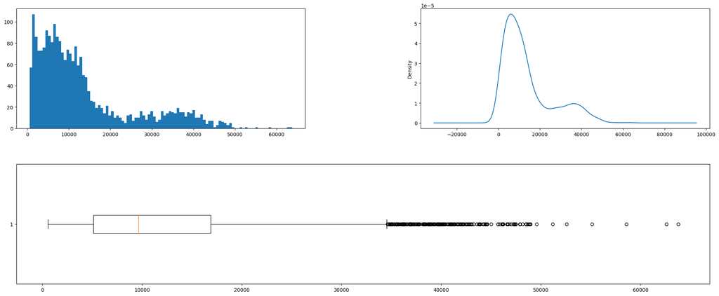

```python
plt.figure(figsize =(25,10))
grid = plt.GridSpec(2, 2, wspace=0.4, hspace=0.3)
plt.subplot(grid[0,0])
plt.hist(master_notv.charges, bins=100)
plt.subplot(grid[0,1])
master_notv.charges.plot.kde()
plt.subplot(grid[1, :])
plt.boxplot(master_notv.charges, vert = False)
plt.show()
```

### WRT Gender

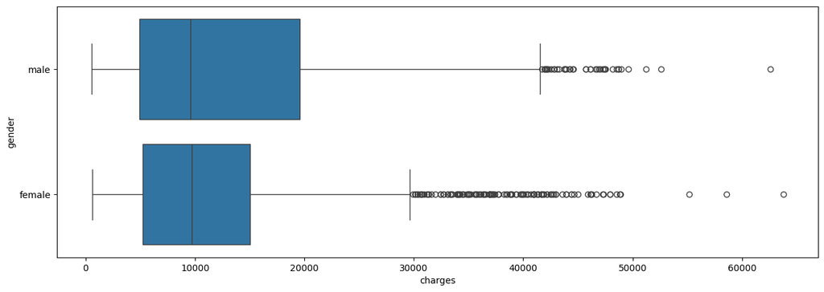

```python
plt.figure(figsize = (15,5))
sns.boxplot(x = 'charges',y = 'gender', data = master_notv)
plt.show()
```

### WRT City tier

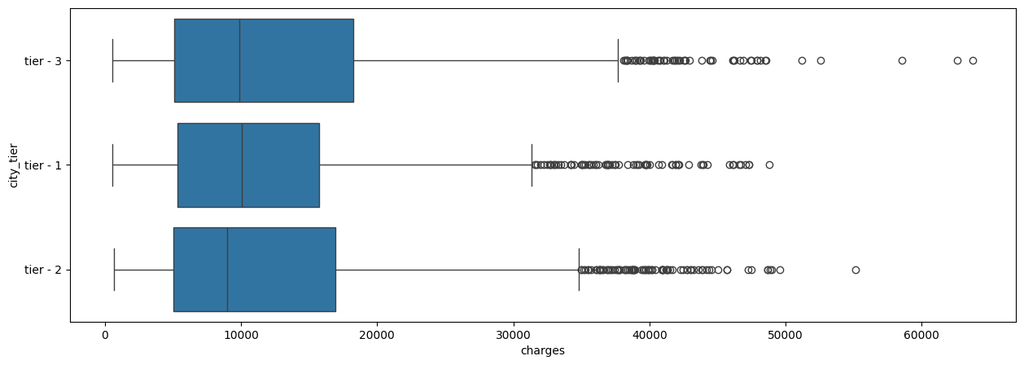

```python
plt.figure(figsize= (15,5))
sns.boxplot(x = 'charges' , y = 'city_tier', data=master_notv)
plt.show()
```

### WRT Hospital tier

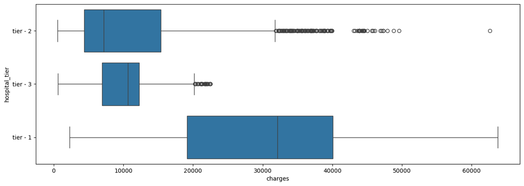

```python
plt.figure(figsize=(15,5))
sns.boxplot(x = 'charges', y = 'hospital_tier' , data = master_notv)
plt.show()
```

## Swarm plot of gender , city_tier & hospital_tier

#### Gender

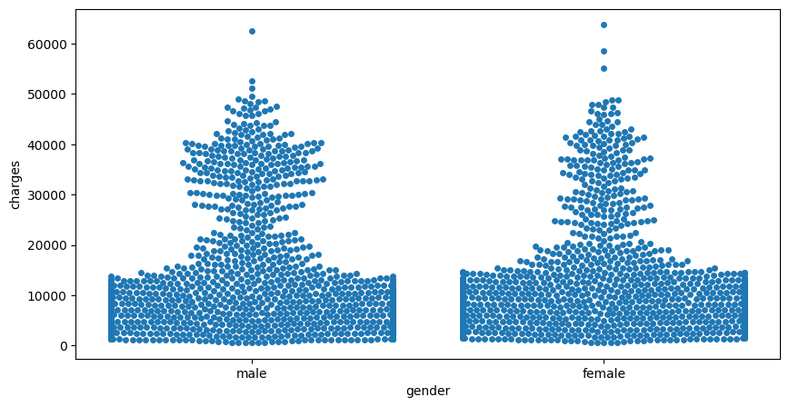

```python
plt.figure(figsize=(10,5))
sns.swarmplot(x = 'gender', y = 'charges', data= master_notv)
plt.show()
```

#### city_tier

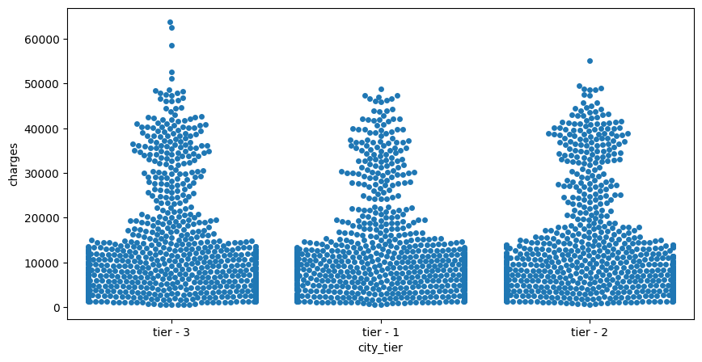

```python
plt.figure(figsize=(10,5))
sns.swarmplot(x = 'city_tier', y = 'charges', data=master_notv)
plt.show()
```

#### hospital_tier

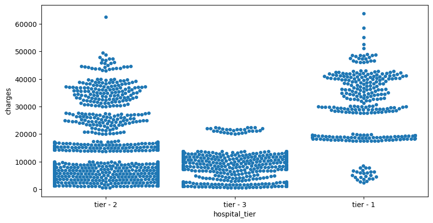

```python
plt.figure(figsize=(10,5))
sns.swarmplot(x = 'hospital_tier', y = 'charges', data=master_notv)
plt.show()
```

### Problem - 11

#### Create a radar chart to showcase the median hospitalization cost for each tier of hospitals

```python
import plotly.express as px
```

```python
median = master_notv.groupby('hospital_tier')[['charges']].median().reset_index()
```

```python
median.T
```

|  | 0 | 1 | 2 |
| --- | --- | --- | --- |
| hospital_tier | tier - 1 | tier - 2 | tier - 3 |
| charges | 32097.435 | 7168.76 | 10676.83 |

```python
fig = px.line_polar(median, r= 'charges', theta='hospital_tier')
fig.show()
```

[interactive chart not shown]

### Problem - 12

#### Create a frequency table and a stacked bar chart to visualize the count of people in the different tiers of cities and hospitals

```python
pd.crosstab(master_notv.city_tier, master_notv.hospital_tier)
```

| hospital_tier city_tier | tier - 1 | tier - 2 | tier - 3 |
| --- | --- | --- | --- |
| tier - 1 | 85 | 403 | 241 |
| tier - 2 | 106 | 479 | 222 |
| tier - 3 | 109 | 452 | 228 |

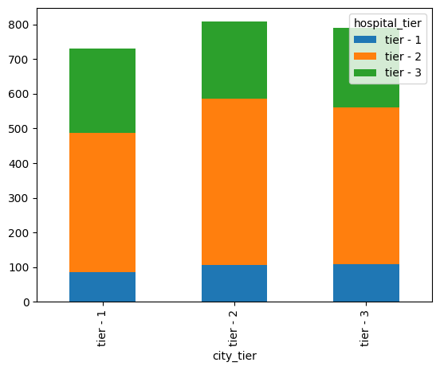

```python
pd.crosstab(master_notv.city_tier, master_notv.hospital_tier).plot.bar(stacked = True)
plt.show()
```

### Problem-13

Test the following null hypotheses:

- Average hospitalization cost across the three types of hospitals is not significantly different
- Average hospitalization cost across the three types of cities is not significantly different
- Average hospitalization cost for smokers is not significantly different than non-smokers
- Smoking and Hearth issues are independent

##### H0 : Average hospitalization cost across the 3 types of hospitals is not significantly different

```python
# ANNOVA TEST
from statsmodels import api as sm
from statsmodels.formula.api import ols
```

```python
mod = ols('charges ~ hospital_tier' , data = master_notv).fit()
```

```python
result = sm.stats.anova_lm(mod)
```

```python
result
```

|  | df | sum_sq | mean_sq | F | PR(>F) |
| --- | --- | --- | --- | --- | --- |
| hospital_tier | 2.0 | 9.763011e+10 | 4.881505e+10 | 493.989566 | 1.773822e-179 |
| Residual | 2322.0 | 2.294554e+11 | 9.881799e+07 | NaN | NaN |

The p-value (PR(>F)) for hospital_tier is 1.773822e-179, indicating a highly significant difference in average hospitalization costs across the three types of hospitals.

#### H0 = Average hospitalization cost across the 3 types of cities is not significantly different

```python
mod = ols('charges ~ city_tier', data= master_notv).fit()
```

```python
result = sm.stats.anova_lm(mod)
```

```python
result
```

|  | df | sum_sq | mean_sq | F | PR(>F) |
| --- | --- | --- | --- | --- | --- |
| city_tier | 2.0 | 4.092192e+08 | 2.046096e+08 | 1.454356 | 0.233763 |
| Residual | 2322.0 | 3.266763e+11 | 1.406874e+08 | NaN | NaN |

#### H0: Average hospitalization cost for smokers is not significantly different than non-smokers

```python
import scipy.stats as stats
```

```python
sample_1 = master_notv.loc[master_notv.smoker == 'yes', 'charges']
sample_2 = master_notv.loc[master_notv.smoker != 'yes', 'charges']
stats.ttest_ind(sample_1,sample_2)
```

```
TtestResult(statistic=74.15560699695726, pvalue=0.0, df=2323.0)
```

The t-test yielded a t-statistic of 74.16 and a p-value of 0.0, leading to the rejection of the null hypothesis.

#### H0 : Smoking and Heart issues are independent

```python
obs_table = pd.crosstab(master_notv.smoker , master_data.heart_issues)
```

```python
obs_table
```

| heart_issues smoker | No | yes |
| --- | --- | --- |
| No | 1108 | 731 |
| yes | 297 | 189 |

```python
chi, p, df, expected = stats.chi2_contingency(obs_table)
```

```python
print('Chi:', chi)
print('P:' ,p)
print('DF:' ,df)
print('Expected:' ,expected)
```

```
Chi: 0.08588150449910657
P: 0.7694797581780767
DF: 1
Expected: [[1111.30967742  727.69032258]
 [ 293.69032258  192.30967742]]
```

Since the p-value (0.7694797581780767) is much greater than any common significance level (e.g., 0.05), you fail to reject the null hypothesis. This means there is not enough evidence to suggest that smoking and heart issues are not independent.

### **`END OF DATA SCIENCE PROBLEMS`**

### Problem No. 1

- Examine the correlation between predictors to identify highly correlated predictors. Use a heatmap to visualize this

```python
master_notv.columns
```

```
Index(['customer_id', 'year', 'month', 'date', 'children', 'charges',
       'hospital_tier', 'city_tier', 'state_id', 'bmi', 'hba1c',
       'heart_issues', 'any_transplants', 'cancer_history',
       'numberofmajorsurgeries', 'smoker', 'name', 'city_tier_ord',
       'hospital_tier_ord', 'state_id_R1013', 'state_id_R1011',
       'state_id_R1012', 'age', 'title', 'gender'],
      dtype='object')
```

```python
master_notv.info()
```

```
<class 'pandas.core.frame.DataFrame'>
Index: 2325 entries, 0 to 2334
Data columns (total 25 columns):
 #   Column                  Non-Null Count  Dtype
---  ------                  --------------  -----
 0   customer_id             2325 non-null   object
 1   year                    2325 non-null   int32
 2   month                   2325 non-null   object
 3   date                    2325 non-null   int64
 4   children                2325 non-null   int64
 5   charges                 2325 non-null   float64
 6   hospital_tier           2325 non-null   object
 7   city_tier               2325 non-null   object
 8   state_id                2325 non-null   object
 9   bmi                     2325 non-null   float64
```

[output cut: 17 more lines]

- eliminate redundant vars like year, month and date, city_tier and hospital_tier as new vars already created

```python
data = master_notv.drop(columns= ['customer_id', 'name', 'year', 'month', 'date', 'hospital_tier',
                                  'city_tier','state_id','title'])
```

```python
data.head()
```

|  | children | charges | bmi | hba1c | heart_issues | any_transplants | cancer_history | numberofmajorsurgeries | smoker | city_tier_ord | hospital_tier_ord | state_id_R1013 | state_id_R1011 | state_id_R1012 | age | gender |
| --- | --- | --- | --- | --- | --- | --- | --- | --- | --- | --- | --- | --- | --- | --- | --- | --- |
| 0 | 0 | 563.84 | 17.58 | 4.51 | No | No | No | 1 | No | 0.0 | 1.0 | 1 | 0 | 0 | 32 | male |
| 1 | 0 | 570.62 | 17.60 | 4.39 | No | No | No | 1 | No | 2.0 | 1.0 | 1 | 0 | 0 | 32 | male |
| 2 | 0 | 600.00 | 16.47 | 6.35 | No | No | Yes | 1 | No | 2.0 | 1.0 | 1 | 0 | 0 | 31 | female |
| 3 | 0 | 604.54 | 17.70 | 6.28 | No | No | No | 1 | No | 0.0 | 0.0 | 1 | 0 | 0 | 32 | male |
| 4 | 0 | 637.26 | 22.34 | 5.57 | No | No | No | 1 | No | 0.0 | 0.0 | 1 | 0 | 0 | 26 | male |

```python
corr_plot = data.select_dtypes(exclude = 'object').corr()
ma = np.ones_like(corr_plot)
ma[np.tril_indices_from(ma)]=0
```

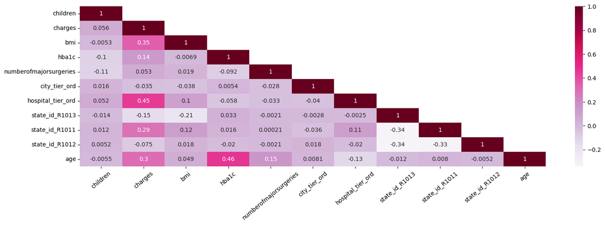

```python
plt.figure(figsize=(18,5))
sns.heatmap(corr_plot, annot=True, mask=ma, cmap='PuRd')
plt.xticks(rotation=40)
plt.show()
```

## Problem 2

Develop a regression model Linear or Ridge. Evaluate the model with k-fold cross validation.Also, ensure that you apply all the following suggestions:

- Implement the stratified 5-fold cross validationtechnique for both model building and validation
- Utilize effective standardization techniques and hyperparameter tuning
- Incorporate sklearn-pipelines to streamline the workflow
- Apply appropriate regularization techniques to address the bias-variance trade-off
- Create five folds in the data, and introduce a variable to identify the folds
- Develop Gradient Boost model and determine the variable importance scores,and identify the redundant variables

```python
# lets first seperate input and output data
final_data = pd.get_dummies(data, drop_first = True,dtype = 'int')
```

```python
final_data.head()
```

|  | children | charges | bmi | hba1c | numberofmajorsurgeries | city_tier_ord | hospital_tier_ord | state_id_R1013 | state_id_R1011 | state_id_R1012 | age | heart_issues_yes | any_transplants_yes | cancer_history_Yes | smoker_yes | gender_male |
| --- | --- | --- | --- | --- | --- | --- | --- | --- | --- | --- | --- | --- | --- | --- | --- | --- |
| 0 | 0 | 563.84 | 17.58 | 4.51 | 1 | 0.0 | 1.0 | 1 | 0 | 0 | 32 | 0 | 0 | 0 | 0 | 1 |
| 1 | 0 | 570.62 | 17.60 | 4.39 | 1 | 2.0 | 1.0 | 1 | 0 | 0 | 32 | 0 | 0 | 0 | 0 | 1 |
| 2 | 0 | 600.00 | 16.47 | 6.35 | 1 | 2.0 | 1.0 | 1 | 0 | 0 | 31 | 0 | 0 | 1 | 0 | 0 |
| 3 | 0 | 604.54 | 17.70 | 6.28 | 1 | 0.0 | 0.0 | 1 | 0 | 0 | 32 | 0 | 0 | 0 | 0 | 1 |
| 4 | 0 | 637.26 | 22.34 | 5.57 | 1 | 0.0 | 0.0 | 1 | 0 | 0 | 26 | 0 | 0 | 0 | 0 | 1 |

```python
x = final_data.drop(['charges'],axis=1)
y = final_data[['charges']]
```

```python
x.head()
```

|  | children | bmi | hba1c | numberofmajorsurgeries | city_tier_ord | hospital_tier_ord | state_id_R1013 | state_id_R1011 | state_id_R1012 | age | heart_issues_yes | any_transplants_yes | cancer_history_Yes | smoker_yes | gender_male |
| --- | --- | --- | --- | --- | --- | --- | --- | --- | --- | --- | --- | --- | --- | --- | --- |
| 0 | 0 | 17.58 | 4.51 | 1 | 0.0 | 1.0 | 1 | 0 | 0 | 32 | 0 | 0 | 0 | 0 | 1 |
| 1 | 0 | 17.60 | 4.39 | 1 | 2.0 | 1.0 | 1 | 0 | 0 | 32 | 0 | 0 | 0 | 0 | 1 |
| 2 | 0 | 16.47 | 6.35 | 1 | 2.0 | 1.0 | 1 | 0 | 0 | 31 | 0 | 0 | 1 | 0 | 0 |
| 3 | 0 | 17.70 | 6.28 | 1 | 0.0 | 0.0 | 1 | 0 | 0 | 32 | 0 | 0 | 0 | 0 | 1 |
| 4 | 0 | 22.34 | 5.57 | 1 | 0.0 | 0.0 | 1 | 0 | 0 | 26 | 0 | 0 | 0 | 0 | 1 |

```python
y.head()
```

|  | charges |
| --- | --- |
| 0 | 563.84 |
| 1 | 570.62 |
| 2 | 600.00 |
| 3 | 604.54 |
| 4 | 637.26 |

```python
# setting a pipeline
from sklearn.linear_model import SGDRegressor,Ridge
from sklearn.pipeline import Pipeline
from sklearn.preprocessing import StandardScaler
from sklearn.model_selection import KFold,StratifiedKFold,RandomizedSearchCV,GridSearchCV
from sklearn.metrics import mean_squared_error
```

```python
pipeline = Pipeline(steps=[('scaler', StandardScaler()), ('regressor', Ridge())])
```

```python
# Defining the parameters for hyperparameter tuning
parameters = {'regressor__alpha': [0.001, 0.01, 0.1, 1, 10, 100]}
```

```python
# Creating KFold objects
kfold = KFold(n_splits=5,shuffle = True,random_state=3)
```

```python
# Creating the Grid saerch object
model_ridge = GridSearchCV(pipeline,param_grid=parameters, cv=kfold, scoring = 'neg_mean_squared_error')
```

```python
model_ridge.fit(x,y)
```

```
GridSearchCV(cv=KFold(n_splits=5, random_state=3, shuffle=True),
             estimator=Pipeline(steps=[('scaler', StandardScaler()),
                                       ('regressor', Ridge())]),
             param_grid={'regressor__alpha': [0.001, 0.01, 0.1, 1, 10, 100]},
             scoring='neg_mean_squared_error')
```

```python
model_ridge.best_params_
```

```
{'regressor__alpha': 10}
```

```python
model_ridge.best_estimator_
```

```
Pipeline(steps=[('scaler', StandardScaler()), ('regressor', Ridge(alpha=10))])
```

## Gradient Boosting Algorithms

```python
from sklearn.ensemble import GradientBoostingRegressor
from sklearn.model_selection import train_test_split
```

```python
x_train,x_test,y_train,y_test = train_test_split(x,y)
```

```python
x_train.head()
```

|  | children | bmi | hba1c | numberofmajorsurgeries | city_tier_ord | hospital_tier_ord | state_id_R1013 | state_id_R1011 | state_id_R1012 | age | heart_issues_yes | any_transplants_yes | cancer_history_Yes | smoker_yes | gender_male |
| --- | --- | --- | --- | --- | --- | --- | --- | --- | --- | --- | --- | --- | --- | --- | --- |
| 1757 | 4 | 33.630 | 5.69 | 1 | 0.0 | 1.0 | 0 | 0 | 0 | 26 | 0 | 0 | 0 | 0 | 1 |
| 1433 | 2 | 35.700 | 4.06 | 1 | 0.0 | 0.0 | 0 | 0 | 0 | 45 | 0 | 0 | 1 | 0 | 1 |
| 1878 | 1 | 25.410 | 10.53 | 1 | 0.0 | 0.0 | 1 | 0 | 0 | 49 | 1 | 0 | 0 | 1 | 1 |
| 998 | 2 | 32.015 | 7.67 | 0 | 2.0 | 0.0 | 0 | 0 | 1 | 46 | 0 | 0 | 0 | 0 | 1 |
| 78 | 0 | 34.400 | 5.70 | 1 | 0.0 | 1.0 | 0 | 1 | 0 | 21 | 0 | 0 | 1 | 0 | 1 |

```python
model = GradientBoostingRegressor()
model.fit(x_train,y_train)
```

```
GradientBoostingRegressor()
```

```python
model.feature_importances_
```

```
array([6.54326802e-03, 1.10257057e-01, 3.74078239e-03, 1.69768576e-04,
       1.87473683e-04, 2.12108910e-02, 5.39569404e-03, 7.01105653e-03,
       1.46504403e-04, 9.36923224e-02, 2.61231651e-04, 8.04305832e-06,
       1.74752877e-04, 7.49677867e-01, 1.52328742e-03])
```

## Variable Importance

```python
pd.DataFrame({'features' : model.feature_names_in_, 'importance' : model.feature_importances_}).sort_values('importance' , ascending=False)
```

|  | features | importance |
| --- | --- | --- |
| 13 | smoker_yes | 0.749678 |
| 1 | bmi | 0.110257 |
| 9 | age | 0.093692 |
| 5 | hospital_tier_ord | 0.021211 |
| 7 | state_id_R1011 | 0.007011 |
| 0 | children | 0.006543 |
| 6 | state_id_R1013 | 0.005396 |
| 2 | hba1c | 0.003741 |
| 14 | gender_male | 0.001523 |
| 10 | heart_issues_yes | 0.000261 |
| 4 | city_tier_ord | 0.000187 |
| 12 | cancer_history_Yes | 0.000175 |
| 3 | numberofmajorsurgeries | 0.000170 |
| 8 | state_id_R1012 | 0.000147 |
| 11 | any_transplants_yes | 0.000008 |

```python
# train score
model.score(x_train,y_train)
```

```
0.9326737646831644
```

```python
# test score
model.score(x_test,y_test)
```

```
0.9266013042387288
```

## Problem No. 3

- Case scenario:

```python
master_data.columns
```

```
Index(['customer_id', 'year', 'month', 'date', 'children', 'charges',
       'hospital_tier', 'city_tier', 'state_id', 'bmi', 'hba1c',
       'heart_issues', 'any_transplants', 'cancer_history',
       'numberofmajorsurgeries', 'smoker', 'name'],
      dtype='object')
```

```python
pred_data = pd.DataFrame({
    'name':['Christopher, Ms. Jayna'],
    'dob':['12/28/1988'],
    'children':[2],
    'bmi':[85/(1.7**2)],
    'hba1c':[5.8],
    'numberofmajorsurgeries':[0],
    'city_tier_ord':[1],
    'hospital_tier_ord':[1],
    'state_id_R1013':[0],
    'state_id_R1011':[1],
    'state_id_R1012':[0],
    'age':[36],
    'heart_issues_yes':[0],
    'any_transplants_yes':[0],
    'cancer_history_Yes':[1],
    'smoker_yes':[1],
    'gender_male':[0]

})
```

```python
pred_data
```

|  | name | dob | children | bmi | hba1c | numberofmajorsurgeries | city_tier_ord | hospital_tier_ord | state_id_R1013 | state_id_R1011 | state_id_R1012 | age | heart_issues_yes | any_transplants_yes | cancer_history_Yes | smoker_yes | gender_male |
| --- | --- | --- | --- | --- | --- | --- | --- | --- | --- | --- | --- | --- | --- | --- | --- | --- | --- |
| 0 | Christopher, Ms. Jayna | 12/28/1988 | 2 | 29.411765 | 5.8 | 0 | 1 | 1 | 0 | 1 | 0 | 36 | 0 | 0 | 1 | 1 | 0 |

```python
pred_data.info()
```

```
<class 'pandas.core.frame.DataFrame'>
RangeIndex: 1 entries, 0 to 0
Data columns (total 17 columns):
 #   Column                  Non-Null Count  Dtype
---  ------                  --------------  -----
 0   name                    1 non-null      object
 1   dob                     1 non-null      object
 2   children                1 non-null      int64
 3   bmi                     1 non-null      float64
 4   hba1c                   1 non-null      float64
 5   numberofmajorsurgeries  1 non-null      int64
 6   city_tier_ord           1 non-null      int64
 7   hospital_tier_ord       1 non-null      int64
 8   state_id_R1013          1 non-null      int64
 9   state_id_R1011          1 non-null      int64
 10  state_id_R1012          1 non-null      int64
 11  age                     1 non-null      int64
 12  heart_issues_yes        1 non-null      int64
 13  any_transplants_yes     1 non-null      int64
 14  cancer_history_Yes      1 non-null      int64
 15  smoker_yes              1 non-null      int64
 16  gender_male             1 non-null      int64
dtypes: float64(2), int64(13), object(2)
memory usage: 268.0+ bytes
```

```python
pred_data['dob'] =  pd.to_datetime(pred_data.dob,errors = 'coerce')
```

```python
pred_data.info()
```

```
<class 'pandas.core.frame.DataFrame'>
RangeIndex: 1 entries, 0 to 0
Data columns (total 17 columns):
 #   Column                  Non-Null Count  Dtype
---  ------                  --------------  -----
 0   name                    1 non-null      object
 1   dob                     1 non-null      datetime64[ns]
 2   children                1 non-null      int64
 3   bmi                     1 non-null      float64
 4   hba1c                   1 non-null      float64
 5   numberofmajorsurgeries  1 non-null      int64
 6   city_tier_ord           1 non-null      int64
 7   hospital_tier_ord       1 non-null      int64
 8   state_id_R1013          1 non-null      int64
 9   state_id_R1011          1 non-null      int64
 10  state_id_R1012          1 non-null      int64
 11  age                     1 non-null      int64
 12  heart_issues_yes        1 non-null      int64
 13  any_transplants_yes     1 non-null      int64
 14  cancer_history_Yes      1 non-null      int64
 15  smoker_yes              1 non-null      int64
 16  gender_male             1 non-null      int64
dtypes: datetime64[ns](1), float64(2), int64(13), object(1)
memory usage: 268.0+ bytes
```

```python
age = 2024 - pred_data.dob.dt.year
age
```

```
0    36
Name: dob, dtype: int32
```

```python
test_data = pred_data.drop(['dob','name'],axis=1)
```

```python
test_data
```

|  | children | bmi | hba1c | numberofmajorsurgeries | city_tier_ord | hospital_tier_ord | state_id_R1013 | state_id_R1011 | state_id_R1012 | age | heart_issues_yes | any_transplants_yes | cancer_history_Yes | smoker_yes | gender_male |
| --- | --- | --- | --- | --- | --- | --- | --- | --- | --- | --- | --- | --- | --- | --- | --- |
| 0 | 2 | 29.411765 | 5.8 | 0 | 1 | 1 | 0 | 1 | 0 | 36 | 0 | 0 | 1 | 1 | 0 |

### Predicting the charges of test_data using best model

```python
model.predict(test_data)
```

```
array([25129.91988605])
```